# ETL, and calling it

## 3 Calling it quits

Another thing I have learned when making this blog, which I didn’t learn during my PhD, is when to call it. Sometimes, you have to know when to quit.

I learned more about how to set up and semi-automate a lot of ETL, but in truth, a lot of this is overkill at least compared to what I usually did for research. Except for the concept of making it modular and using helper functions that all play together, adding `run_id`, quarantining (especially if the studied cohort is small), and making quality reports for each run.

Below are additional reasons that I am not motivated to finish this blog post.

- These are not real data, for a real job, no stakes
- This hasn’t been produced as part of a greater whole, with a team, a project or trial

**These blog posts should be more modular, just like the code above, and serve a clear, distinct purpose. Some specific skill I would like to learn, or code I want to understand.**

Working with simulated data alone like this is just getting frustrating.

So I will end the post with the following: Learn WHEN to quit - and move on to something else. With that also ofcourse comes learning when NOT to quit.

And a plot for the thumbnail:

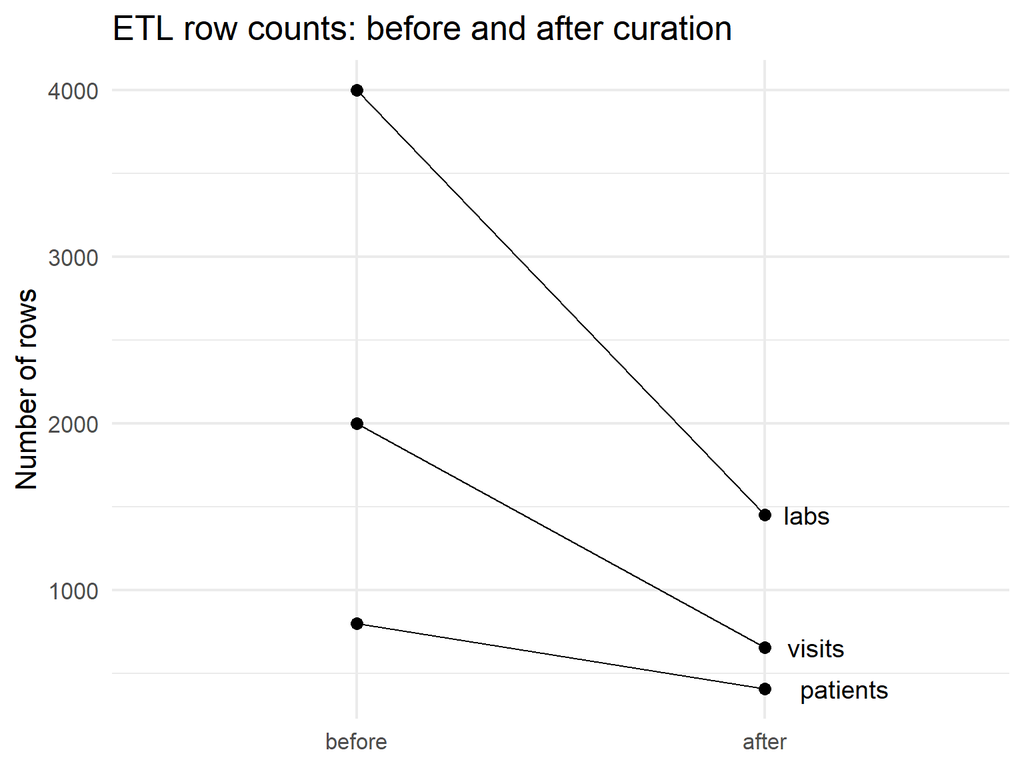

```r
library(ggplot2)
library(tidyr)

counts <- tibble(
  dataset = c("patients", "visits", "labs"),
  before = c(
    nrow(read_csv(file.path(raw_dir, "patients.csv"), show_col_types = FALSE)),
    nrow(read_csv(file.path(raw_dir, "visits.csv"), show_col_types = FALSE)),
    nrow(read_csv(file.path(raw_dir, "labs.csv"), show_col_types = FALSE))
  ),
  after = c(
    nrow(read_parquet(file.path(warehouse_dir, "dim_patient.parquet"))),
    nrow(read_parquet(file.path(warehouse_dir, "fact_visit.parquet"))),
    nrow(read_parquet(file.path(warehouse_dir, "fact_lab.parquet")))
  )
)

plot_df <- counts |>
  pivot_longer(
    cols = c(before, after),
    names_to = "stage",
    values_to = "n"
  ) |>
  mutate(
    stage = factor(stage, levels = c("before", "after")),
    dataset = factor(dataset, levels = c("patients", "visits", "labs"))
  )

ggplot(plot_df, aes(x = stage, y = n, group = dataset)) +
  geom_line() +
  geom_point(size = 3) +
  geom_text(
    data = subset(plot_df, stage == "after"),
    aes(label = dataset),
    hjust = -0.4,
    size = 5,
    show.legend = FALSE
  ) +
  expand_limits(x = 2.2) +
  labs(
    title = "ETL row counts: before and after curation",
    x = NULL,
    y = "Number of rows"
  ) +
  theme_minimal(base_size = 16)
```

```r
ggsave("thumbnail.jpg", plot = last_plot())
```

## 4 Refactored

```
# chunk-generate-data ----------------------------------------------------

packages <- c(
  "readr",
  "dplyr",
  "stringr",
  "lubridate",
  "janitor",
  "arrow",
  "digest",
  "logger",
  "jsonlite",
  "purrr",
  "tibble",
  "here"
)

invisible(lapply(packages, \(pkg) {
  if (!require(pkg, character.only = TRUE)) {
    install.packages(pkg)
  }
  library(pkg, character.only = TRUE)
}))

set.seed(1)

base_dir <- here::here("posts", "2026-03-25-etl")
raw_dir <- file.path(base_dir, "data", "raw")
staging_dir <- file.path(base_dir, "data", "staging")
warehouse_dir <- file.path(base_dir, "data", "warehouse")

walk(
  c(raw_dir, staging_dir, warehouse_dir),
  dir.create,
  recursive = TRUE,
  showWarnings = FALSE
)

patients <- tibble(
  patient_id = sample(c(paste0("P", 1:500), "P10", "P10 "), 800, TRUE),
```

[output cut: 542 more lines]

```
    )
  )
)

load_warehouse(
  dim_patient = curated$dim_patient,
  fact_visit = curated_checked$fact_visit,
  fact_lab = curated_checked$fact_lab,
  quarantine_patient = curated$quarantine_patient,
  quarantine_visit = quarantine_visit_all,
  quarantine_lab = quarantine_lab_all,
  run_id = run_id
)

log_info("ETL done, run_id={run_id}")
```

## Footnotes

[^1]: % of haemoglobin A1c in the red blood cells that has glucose attached
[^2]: https://www.hba1cnet.com/hba1c-calculator/
[^3]: https://unitslab.com/node/44